# League of Legends High Elo Ranked Games - Exploratory Data Analysis

### 3. What does average level look like on red and blue sides in relation to game duration?

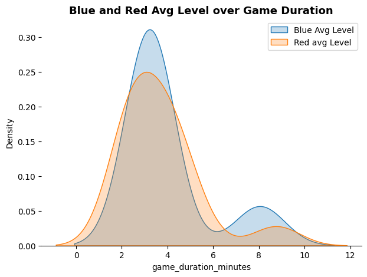

```python
# Making another kernel density estimate (KDE) plot

# States that we want to create 1 plot on 1 axes, for a total of 1 visualization and the what the size should be
# These are super configurable parts of matplotlib
fig, ax = plt.subplots(1,1,figsize=(7,5))

# We're adding two lines, one for each of the columns we want to visualize
# This states what kind of visualization should go on the plot we created
sb.kdeplot(df[df['blueAvgLevel']==1]['game_duration_minutes'], shade=True)
sb.kdeplot(df[df['redAvgLevel']==0]['game_duration_minutes'], shade=True)

# Adds a legends that we can name specifically
plt.legend(['Blue Avg Level','Red avg Level'])

# Adds a title
ax.set_title('Blue and Red Avg Level over Game Duration', fontdict={'size': 13, 'weight': 'semibold'})

# Hiding what I don't want to see

# Hides the top bar
ax.spines['top'].set_visible(False)
# Hides the left bar
ax.spines['left'].set_visible(False)
# Hides the right bar
ax.spines['right'].set_visible(False)
# Hides the Y axis ticks - which we don't need since we labeled the bars
#plt.yticks([])
# Hides the X axis label - which we don't need since the bars clear show what they are
#plt.xlabel('')

# Show the plot
plt.show()
```

> It is surprising to see blue with larger peaks in average level, considering that red side wins slightly more. One possible explanation is that levels are more evenly distributed amongst the team on blue side while teams on red side tend to rely more heavily on one or two players to carry the game and do the most amount of damage.

### 4. What can we see if we look at several variables in comparison to each other?

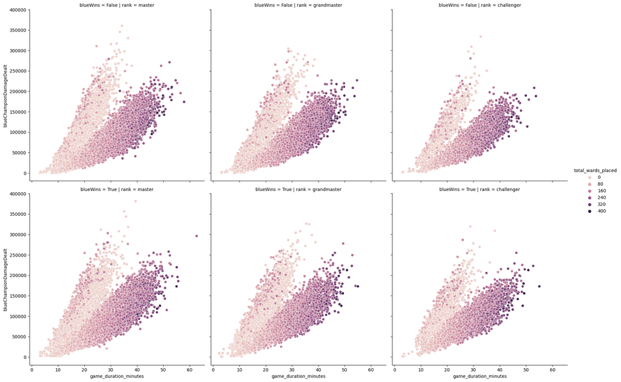

```python
# Creating relation plots onto a grid with Seaborn

# Calling rel plot and choosing the values for y and x axes based on our dataframe
sb.relplot(data = df, y="blueChampionDamageDealt", x="game_duration_minutes",
           # Sets the variable for the rows
           row="blueWins",
           # Sets the variable for the columns
           col="rank",
           # Specifies what numbers the colors should represent
           hue="total_wards_placed",
           # Sets the hieght (in inches) of the visualization
           height=6)
```

> We can see here that the numbers from all variables fit in a smaller range the higher rank the games are. This reflects the nature of playing at the highest ranks and how very little mistakes can lose the game. The result is that overall, games last less time and less damage is dealt the higher the rank.

> What's interesting is that there are two "wings" of damage dealt. This indicates that games are most often won (and lost) in either a slow and steady fashion or rapidly, in what many players call "snowballing". We can also see that a large number of ward placements is less likely to be achieved when the game (and damage) happens in a quicker succession.

### 5. What can we see if we look at data correlations?

> We don't want correlations of ALL the columns, so we'll create a copy of our dataframe and then drop the columns we don't want to see. Then we'll use .corr() to find correlations in the data using the Pearson method. Lastly, we'll visualize these correlations in a seaborn heatmap and see what we can find!

```python
df_corr = df.copy()
```

```python
df_corr.columns
```

```
Index(['gameId', 'gameDuraton', 'blueWins', 'blueFirstBlood', 'blueFirstTower',
       'blueFirstBaron', 'blueFirstDragon', 'blueFirstInhibitor',
       'blueDragonKills', 'blueBaronKills', 'blueTowerKills',
       'blueInhibitorKills', 'blueWardPlaced', 'blueWardkills', 'blueKills',
       'blueDeath', 'blueAssist', 'blueChampionDamageDealt', 'blueTotalGold',
       'blueTotalMinionKills', 'blueTotalLevel', 'blueAvgLevel',
       'blueJungleMinionKills', 'blueKillingSpree', 'blueTotalHeal',
       'blueObjectDamageDealt', 'redWins', 'redFirstBlood', 'redFirstTower',
       'redFirstBaron', 'redFirstDragon', 'redFirstInhibitor',
       'redDragonKills', 'redBaronKills', 'redTowerKills', 'redInhibitorKills',
       'redWardPlaced', 'redWardkills', 'redKills', 'redDeath', 'redAssist',
       'redChampionDamageDealt', 'redTotalGold', 'redTotalMinionKills',
       'redTotalLevel', 'redAvgLevel', 'redJungleMinionKills',
       'redKillingSpree', 'redTotalHeal', 'redObjectDamageDealt', 'rank',
       'game_duration_minutes', 'total_wards_placed', 'total_wards_killed'],
      dtype='object')
```

```python
df_corr.drop(['gameId', 'blueWardPlaced', 'blueWardkills', 'blueKills',
       'blueDeath', 'blueAssist', 'blueChampionDamageDealt', 'blueTotalGold',
       'blueTotalMinionKills', 'blueTotalLevel', 'blueAvgLevel',
       'blueJungleMinionKills', 'blueKillingSpree', 'blueTotalHeal',
       'blueObjectDamageDealt', 'redWardPlaced', 'redWardkills', 'redKills', 'redDeath', 'redAssist',
       'redChampionDamageDealt', 'redTotalGold', 'redTotalMinionKills',
       'redTotalLevel', 'redAvgLevel', 'redJungleMinionKills',
       'redKillingSpree', 'redTotalHeal', 'redObjectDamageDealt', 'rank',
       'game_duration_minutes', 'total_wards_placed', 'total_wards_killed'],axis=1, inplace=True)
```

```python
df_corr.columns
```

```
Index(['gameDuraton', 'blueWins', 'blueFirstBlood', 'blueFirstTower',
       'blueFirstBaron', 'blueFirstDragon', 'blueFirstInhibitor',
       'blueDragonKills', 'blueBaronKills', 'blueTowerKills',
       'blueInhibitorKills', 'redWins', 'redFirstBlood', 'redFirstTower',
       'redFirstBaron', 'redFirstDragon', 'redFirstInhibitor',
       'redDragonKills', 'redBaronKills', 'redTowerKills',
       'redInhibitorKills'],
      dtype='object')
```

```python
corr = df_corr.corr()
```

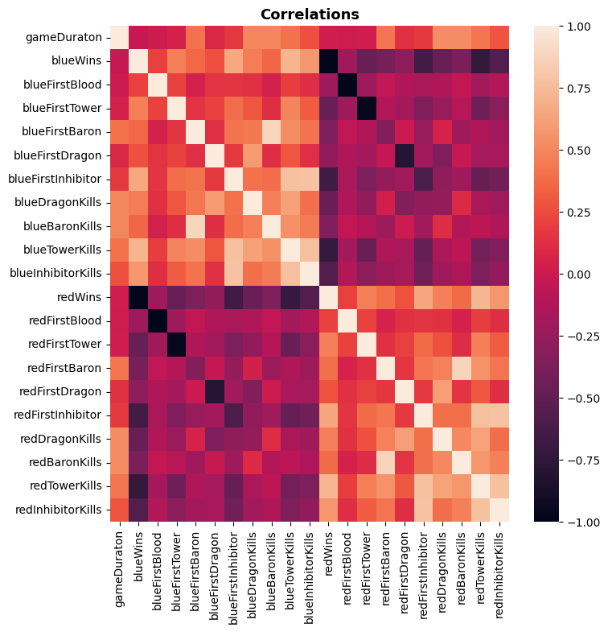

```python
# Configuring the size of the plot.
plt.figure(figsize=(8, 8))

# Calling the heatmap and passing the data we prepared through it.
ax = sb.heatmap(corr)

# Adds a title to our plot
ax.set_title('Correlations', fontdict={'size': 13, 'weight': 'semibold'})
```

> Wow! A lot of really interesting things here. The first thing I want to note is that first blood on both blue or red side, is NOT strongly correlated with anything. This is important, because (especially in high ranked games) many players get instantly upset and proclaim that the game is lost as soon as the opposite team gets the first kill (first blood). This practice of getting upset is called getting "tilted". Getting tilted can lead a player to get continually upset or annoyed, make rash decisions, and not play as well as they would have otherwise. This is as much a mental game as it is a skill based one.

> The next thing I want to point out is that first tower is only weakly associated with winning for both red and blue sides. This is another common circumstance that is very likely to tilt a player. The incident of losing one of your team's towers first, especially before the 15 minute mark, has a super high likelihood of upsetting someone on the team to the point where they might just disconnect or stop trying, because they truly believe the game is over.

> The variables most associated with winning for both blue and red sides are first inhibitor and tower kills. This would imply that if you want to win, your focus should be on the ultimate objective of destroying inhibitors and towers. This is not to say that secondary objectives such as securing dragon and possibly baron are not important, merely that they are natural occurrences if you've secured towers because you will be better positioned.

### Talk about some of the relationships you observed in this part of the investigation. Were there features that strengthened each other in terms of looking at your feature(s) of interest?

> Red side typically places more wards and that leads me to believe this is the reason they win slightly more than blue side does. A reason for this is because players tend to favor/feel more comfortable on blue side and the worry about being behind or playing with a disadvantage could lead them to compensate by prioritizing vision.

> Looking at champion damage dealt visualized the experience of slow and steady games vs snowballing. Snowballing is less common the higher the rank game is. It also further reinforced the notion that numbers from all variable fit smaller ranged the higher rank the games are.

> First inhibitor and tower kills are the variable most indicative of a win for a team playing on either red or blue side.

### Were there any interesting or surprising interactions between features?

> What was most surprising is that neither first blood nor first tower were strong indicators of a team winning the game. This is surprising because they are the two most common things to make players angry and lead to them ending the game early.

## Conclusions

> Vision (placing wards) is considerably important if a team wants to win. All members of the team must participate in order to reach higher levels of wards placed. Smaller mistakes/numbers matter more the higher ranked you are and your aim should be to allow yourself to scale in order to make steady progress and win over the course of the game. Regardless of rank, neither first blood nor first tower are indicative that the game is lost and players should work hard to maintain a balanced and positive mental outlook in the face of these experiences. The focus should instead be on pushing for the first inhibitor and the destruction of towers, as these are the highest indicators of a won game.

```python
df.to_csv('Ranked Games df_final.csv', index=None)
df_test = pd.read_csv('Ranked Games df_final.csv')
```

```python
df_test.head()
```

|  | gameId | gameDuraton | blueWins | blueFirstBlood | blueFirstTower | blueFirstBaron | blueFirstDragon | blueFirstInhibitor | blueDragonKills | blueBaronKills | blueTowerKills | blueInhibitorKills | blueWardPlaced | blueWardkills | blueKills | blueDeath | blueAssist | blueChampionDamageDealt | blueTotalGold | blueTotalMinionKills | blueTotalLevel | blueAvgLevel | blueJungleMinionKills | blueKillingSpree | blueTotalHeal | blueObjectDamageDealt | redWins | redFirstBlood | redFirstTower | … |
| --- | --- | --- | --- | --- | --- | --- | --- | --- | --- | --- | --- | --- | --- | --- | --- | --- | --- | --- | --- | --- | --- | --- | --- | --- | --- | --- | --- | --- | --- | --- |
| 0 | 4227123625 | 1429 | False | True | True | False | False | False | 0 | 0 | 4 | 0 | 75 | 33 | 7 | 19 | 13 | 42979 | 41910 | 646 | 60 | 12.0 | 180 | 2 | 15575 | 35335 | True | False | False | … |
| 1 | 4219545724 | 1313 | False | False | True | False | False | False | 0 | 0 | 3 | 0 | 45 | 13 | 6 | 22 | 9 | 36087 | 35880 | 563 | 56 | 11.2 | 119 | 1 | 13059 | 26348 | True | True | False | … |
| 2 | 4219463634 | 1660 | True | False | False | True | True | True | 1 | 1 | 9 | 2 | 66 | 31 | 30 | 13 | 61 | 64708 | 58214 | 651 | 74 | 14.8 | 209 | 7 | 37288 | 64577 | False | True | True | … |
| 3 | 4205778093 | 984 | True | True | True | False | True | False | 2 | 0 | 5 | 0 | 55 | 9 | 26 | 3 | 34 | 45772 | 36545 | 402 | 53 | 10.6 | 102 | 6 | 14093 | 31303 | False | False | False | … |
| 4 | 4201063474 | 1437 | False | True | True | False | True | False | 2 | 0 | 3 | 0 | 75 | 23 | 19 | 24 | 22 | 79501 | 42395 | 528 | 60 | 12.0 | 96 | 5 | 23863 | 30643 | True | False | False | … |